# Breast Cancer Wisconsin (Diagnostic) Data Set (from kaggle.com)

A small project analyzing the Breast Cancer Wisconsin (Diagnostic) Data Set. The data set provides measurements of breast cancer cells to determine whether cancer cells are malignant or benign. The measured attributes are

a) radius (mean of distances from center to points on the perimeter)

b) texture (standard deviation of gray-scale values)

c) perimeter

d) area

e) smoothness (local variation in radius lengths)

f) compactness (perimeter^2 / area - 1.0)

g) concavity (severity of concave portions of the contour)

h) concave points (number of concave portions of the contour)

i) symmetry

j) fractal dimension ("coastline approximation" - 1)

For each attribute the mean value, standard deviation and worst (mean value of three biggest values) values were measured. In order to start analyzing load necessary packages:

```python
import pandas as pd
import matplotlib.pyplot as plt
from sklearn import tree
from sklearn import cross_validation
from sklearn.ensemble import RandomForestClassifier

#make pretty plots in notebook
%matplotlib inline

#import file for visualization
import ModelLearningCurve as mlc
```

Load the data

```python
cancer_table = pd.read_csv("data.csv" )
```

Getting to know the data

```python
cancer_table.count()
```

```
id                         569
diagnosis                  569
radius_mean                569
texture_mean               569
perimeter_mean             569
area_mean                  569
smoothness_mean            569
compactness_mean           569
concavity_mean             569
concave points_mean        569
symmetry_mean              569
fractal_dimension_mean     569
radius_se                  569
texture_se                 569
perimeter_se               569
area_se                    569
smoothness_se              569
compactness_se             569
concavity_se               569
concave points_se          569
symmetry_se                569
fractal_dimension_se       569
radius_worst               569
texture_worst              569
perimeter_worst            569
area_worst                 569
smoothness_worst           569
compactness_worst          569
concavity_worst            569
concave points_worst       569
symmetry_worst             569
fractal_dimension_worst    569
Unnamed: 32                  0
dtype: int64
```

```python
cancer_table.head(3)
```

|  | id | diagnosis | radius_mean | texture_mean | perimeter_mean | area_mean | smoothness_mean | compactness_mean | concavity_mean | concave points_mean | ... | texture_worst | perimeter_worst | area_worst | smoothness_worst | compactness_worst | concavity_worst | concave points_worst | symmetry_worst | fractal_dimension_worst | Unnamed: 32 |
| --- | --- | --- | --- | --- | --- | --- | --- | --- | --- | --- | --- | --- | --- | --- | --- | --- | --- | --- | --- | --- | --- |
| 0 | 842302 | M | 17.99 | 10.38 | 122.8 | 1001.0 | 0.11840 | 0.27760 | 0.3001 | 0.14710 | ... | 17.33 | 184.6 | 2019.0 | 0.1622 | 0.6656 | 0.7119 | 0.2654 | 0.4601 | 0.11890 | NaN |
| 1 | 842517 | M | 20.57 | 17.77 | 132.9 | 1326.0 | 0.08474 | 0.07864 | 0.0869 | 0.07017 | ... | 23.41 | 158.8 | 1956.0 | 0.1238 | 0.1866 | 0.2416 | 0.1860 | 0.2750 | 0.08902 | NaN |
| 2 | 84300903 | M | 19.69 | 21.25 | 130.0 | 1203.0 | 0.10960 | 0.15990 | 0.1974 | 0.12790 | ... | 25.53 | 152.5 | 1709.0 | 0.1444 | 0.4245 | 0.4504 | 0.2430 | 0.3613 | 0.08758 | NaN |

3 rows × 33 columns

## Data cleaning

Cleaning data of unwanted unnamed column, id and possible NaN values (which weren't present in the data set)

```python
cancer_table.drop('Unnamed: 32', axis=1, inplace=True)
cancer_table.drop('id', axis=1, inplace=True)
cancer_table.dropna(inplace=True)
```

Check whether the categories 'M'(=malignant) and 'B'(=benign) are biased

```python
malignant_count =  len(cancer_table[cancer_table['diagnosis']=='M'].index)
benign_count =  len(cancer_table[cancer_table['diagnosis']=='B'].index)
malignant_perc = malignant_count/float((malignant_count + benign_count))*100
print("Percentage of malignant cells:  %0.2f%%" % malignant_perc)
```

```
Percentage of malignant cells:  37.26%
```

The small discovered mismatch in favor of benign cancer cells should not cause a problem for further investigation.

## Feature Selection

Because there is a large feature set compared with the number of data points some feature selection might be appropriate. For example the perimeter as well as the area are, in theory, derived values from the radius. Therefore they should be highly correlated, without adding further information to a chosen classifier. In order to investigate that I am creating a scatterplot of the radius over the two derived variables, where magenta points denote malignant cancer cells and blue points are benign cancer cells.

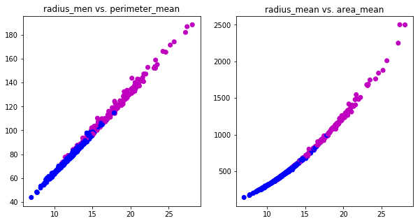

```python
f, (ax1, ax2) = plt.subplots(1, 2)
f.set_figheight(5)
f.set_figwidth(10)
ax1.scatter(cancer_table['radius_mean'],cancer_table['perimeter_mean'],marker='o', c=cancer_table['diagnosis'])
ax1.set_title("radius_men vs. perimeter_mean")
ax2.scatter(cancer_table['radius_mean'],cancer_table['area_mean'],marker='o', c=cancer_table['diagnosis'])
ax2.set_title("radius_mean vs. area_mean")
plt.show()
```

As expected the relation between the radius and the perimeter is nearly perfectly linear whereas the relation between the radius and the area has a quadratic form (funnily for bigger cells the relation seems to become linear) and both variables are highly correlated with the radius. Therefore there is not much information gain when adding these two features in addition to the radius and I will drop these from the data frame. To simplify the model further I will concentrate on the mean values in a first approach and drop the standard deviation and worst values (although especially the worst values might add some value to the classifier I want to start with a simpler model).

A more sophisticated approach would be to perform a PCA in order to gain an orthogonal, uncorrelated feature set with the dowside of losing the intuitive sense for the used features.

```python
cancer_table.drop(cancer_table.columns.values[11:31], axis=1, inplace=True)
cancer_table.drop('area_mean', axis=1, inplace=True)
cancer_table.drop('perimeter_mean', axis=1, inplace=True)
```

## First conclusion

Note that the plots also already reveal an interesting fact: the bigger the cells, the more likely it seems, that the cancer is malignant.

## Classification Using a Decision Tree

In this section I use a simple decision tree to describe the data, plot the learning curve in order to see whether the provided number of data points is able to sample the given feature space and then I procced by enhancing the model in the next section. First of all the data is split in features and the target

```python
features = cancer_table.drop('diagnosis', axis=1)
target = cancer_table['diagnosis']
```

As a next step the learning curve for a decision tree is plotted, i.e. the data is split into different sizes of samples, and for each sample a cross-validation is performed. The resulting training and testing score (mean value of the performed cross validation score) is then plotted over the size of the sample. A converging testing score indicates a good sampling of the feature space and adding more data to the set does not change the outcome of the predictor much. In order to avoid overly complex trees the max_depth was limited to 10.

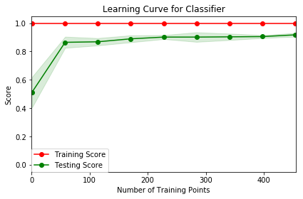

```python
clf_tree = tree.DecisionTreeClassifier(random_state=1, max_depth=10)
mlc.ModelLearningCurveClassification(clf_tree, features, target)
```

The greenish area shows the standard deviation for the cross vaildated scores. As can be seen in the figure the classifier's testing score (accuracy in this case) converges nicely at about 90% and doesn't change too much between 200-500 data points.The cross validated score for the whole set of training samples cand be found below

```python
crossValScore=cross_validation.cross_val_score(clf_tree, features, target, cv=5)
print("Test accuracy decision tree: %0.2f (+/- %0.2f)" % (crossValScore.mean(), crossValScore.std() * 2))
```

```
Test accuracy decision tree: 0.91 (+/- 0.04)
```

The mean value of the cross validated test accuracy is already pretty high with 91% considering the rather simple model. The 2$\sigma$ interval is 4%.

## Classification Using a Random Forest

The same learning curve as above was evaluated using a random tree forest.

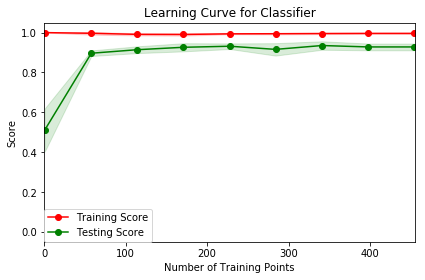

```python
clf_forest = RandomForestClassifier(random_state=1)
mlc.ModelLearningCurveClassification(clf_forest, features, target)
```

```python
crossValScore=cross_validation.cross_val_score(clf_forest, features, target, cv=5)
print("Accuracy random forest: %0.2f (+/- %0.2f)" % (crossValScore.mean(), crossValScore.std() * 2))
```

```
Accuracy random forest: 0.94 (+/- 0.05)
```

The accuracy can be raised to 94% using a random forest, while the 2$\sigma$ interval slightly raises to +/-5%.

A nice property of random forests is that the importance of each feature can be evaluated. Below the whole data set is used to train the forest and the feature importance is shown

```python
clf_forest.fit(features,target)
#Advantage in random forests: one gets feature importance for free
featimp = pd.Series(clf_forest.feature_importances_, index=features.columns.values).sort_values(ascending=False)
featimp
```

```
concave points_mean       0.356207
concavity_mean            0.223409
radius_mean               0.164507
compactness_mean          0.099088
texture_mean              0.063174
fractal_dimension_mean    0.038300
smoothness_mean           0.032628
symmetry_mean             0.022687
dtype: float64
```

## Where to go from here

To further improve the prediction the features could be further selected using only the top five features found from the random forest classifier and additionaly taking worst values and standard devaiations into account. On top of that the classifier itself might be improved by performing a grid-search on the parameter space of the random forest (for example max_depth and n_estimators) to optimize the model.